# Big Mac Index

## Our Big Mac index shows how burger prices are changing

- [Economist Site](https://www.economist.com/big-mac-index)
- [GitHub Site](https://github.com/TheEconomist/big-mac-data)

### What is Big Mac Index?

**Quote From the [Economist Site](https://www.economist.com/big-mac-index)**

The big mac index was invented by The Economist in 1986 as a lighthearted guide to whether currencies are at their “correct” level. It is based on the theory of purchasing-power parity (PPP), the notion that in the long run exchange rates should move towards the rate that would equalise the prices of an identical basket of goods and services (in this case, a burger) in any two countries.

Burgernomics was never intended as a precise gauge of currency misalignment, merely a tool to make exchange-rate theory more digestible. Yet the Big Mac index has become a global standard, included in several economic textbooks and the subject of dozens of academic studies. For those who take their fast food more seriously, we also calculate a gourmet version of the index.

#### RAW Index

**The British pound is 12.9% undervalued against the US dollar January 2023**

A Big Mac costs £3.79 in Britain and US$5.36 in the United States. The implied exchange rate is 0.71. The difference between this and the actual exchange rate, 0.81, suggests the British pound is 12.9% undervalued

#### GDP Adjusted

**The British pound is 7.2% undervalued against the US dollar January 2023**

A Big Mac costs 12.9% less in Britain (US$4.67) than in the United States (US$5.36) at market exchange rates. Based on differences in GDP per person, a Big Mac should cost 6.1% less. This suggests the pound is 7.2% undervalued

### Setup - Importing Full Data

```r
library(tidyverse)
library(lubridate)
```

```r
url_full <- "https://TheEconomist.github.io/big-mac-data/output-data/big-mac-full-index.csv"
```

```r
df_url <- read_csv(url_full); df_url
```

```
Error in open.connection(5L, "rb") : HTTP error 404.
```

```r
bigmac <- read_csv("./data/big-mac-full-index.csv"); bigmac
```

| date | iso_a3 | currency_code | name | local_price | dollar_ex | dollar_price | USD_raw | EUR_raw | GBP_raw | JPY_raw | CNY_raw | GDP_bigmac | adj_price | USD_adjusted | EUR_adjusted | GBP_adjusted | JPY_adjusted | CNY_adjusted |
| --- | --- | --- | --- | --- | --- | --- | --- | --- | --- | --- | --- | --- | --- | --- | --- | --- | --- | --- |
| 2000-04-01 | ARG | ARS | Argentina | 2.500000e+00 | 1.000000e+00 | 2.5000000 | 0.11607 | 0.05007 | -0.16722 | -0.09864 | 1.09091 | 7.803329e+03 | 1.922652 | 0.39117 | NA | -0.06626 | 0.10096 | 0.97153 |
| 2000-04-01 | AUS | AUD | Australia | 2.590000e+00 | 1.680000e+00 | 1.5416667 | -0.31176 | -0.35246 | -0.48645 | -0.44416 | 0.28939 | 2.914488e+04 | 2.301550 | -0.28335 | NA | -0.51898 | -0.43285 | 0.01563 |
| 2000-04-01 | BRA | BRL | Brazil | 2.950000e+00 | 1.790000e+00 | 1.6480447 | -0.26427 | -0.30778 | -0.45102 | -0.40581 | 0.37836 | 4.822739e+03 | 1.869734 | -0.05696 | NA | -0.36704 | -0.25369 | 0.33645 |
| 2000-04-01 | CAN | CAD | Canada | 2.850000e+00 | 1.470000e+00 | 1.9387755 | -0.13448 | -0.18566 | -0.35417 | -0.30099 | 0.62152 | 2.608733e+04 | 2.247266 | -0.07698 | NA | -0.38047 | -0.26953 | 0.30809 |
| 2000-04-01 | CHE | CHF | Switzerland | 5.900000e+00 | 1.700000e+00 | 3.4705882 | 0.54937 | 0.45774 | 0.15609 | 0.25130 | 1.90267 | 2.387272e+04 | 2.207948 | 0.68172 | NA | 0.12876 | 0.33090 | 1.38330 |
| 2000-04-01 | CHL | CLP | Chile | 1.260000e+03 | 5.140000e+02 | 2.4513619 | 0.09436 | 0.02964 | -0.18342 | -0.11618 | 1.05023 | 4.640837e+03 | 1.866505 | 0.40514 | NA | -0.05688 | 0.11201 | 0.99133 |
| 2000-04-01 | CHN | CNY | China | 9.900000e+00 | 8.280000e+00 | 1.1956522 | -0.46623 | -0.49779 | -0.60171 | -0.56891 | 0.00000 | 1.620622e+03 | 1.812884 | -0.29437 | NA | -0.52639 | -0.44157 | 0.00000 |
| 2000-04-01 | CZE | CZK | Czech Republic | 5.437000e+01 | 3.910000e+01 | 1.3905371 | -0.37922 | -0.41594 | -0.53680 | -0.49865 | 0.16299 | 9.020845e+03 | 1.944267 | -0.23481 | NA | -0.48641 | -0.39444 | 0.08441 |
| 2000-04-01 | DNK | DKK | Denmark | 2.475000e+01 | 8.040000e+00 | 3.0783582 | 0.37427 | 0.29299 | 0.02544 | 0.10988 | 1.57463 | 2.114657e+04 | 2.159548 | 0.52509 | NA | 0.02363 | 0.20694 | 1.16133 |
| 2000-04-01 | EUZ | EUR | Euro area | 2.560000e+00 | 1.075269e+00 | 2.3808000 | 0.06286 | 0.00000 | -0.20693 | -0.14162 | 0.99121 | NA | NA | NA | NA | NA | NA | NA |

[output cut: 990 more lines]

```r
glimpse(bigmac)
```

```
Rows: 1,631
Columns: 19
$ date          <date> 2000-04-01, 2000-04-01, 2000-04-01, 2000-04-01, 2000-04-01, 2000-04-…
$ iso_a3        <chr> "ARG", "AUS", "BRA", "CAN", "CHE", "CHL", "CHN", "CZE", "DNK", "EUZ",…
$ currency_code <chr> "ARS", "AUD", "BRL", "CAD", "CHF", "CLP", "CNY", "CZK", "DKK", "EUR",…
$ name          <chr> "Argentina", "Australia", "Brazil", "Canada", "Switzerland", "Chile",…
$ local_price   <dbl> 2.50, 2.59, 2.95, 2.85, 5.90, 1260.00, 9.90, 54.37, 24.75, 2.56, 1.90…
$ dollar_ex     <dbl> 1.0000000, 1.6800000, 1.7900000, 1.4700000, 1.7000000, 514.0000000, 8…
$ dollar_price  <dbl> 2.500000, 1.541667, 1.648045, 1.938776, 3.470588, 2.451362, 1.195652,…
$ USD_raw       <dbl> 0.11607, -0.31176, -0.26427, -0.13448, 0.54937, 0.09436, -0.46623, -0…
$ EUR_raw       <dbl> 0.05007, -0.35246, -0.30778, -0.18566, 0.45774, 0.02964, -0.49779, -0…
$ GBP_raw       <dbl> -0.16722, -0.48645, -0.45102, -0.35417, 0.15609, -0.18342, -0.60171, …
$ JPY_raw       <dbl> -0.09864, -0.44416, -0.40581, -0.30099, 0.25130, -0.11618, -0.56891, …
$ CNY_raw       <dbl> 1.09091, 0.28939, 0.37836, 0.62152, 1.90267, 1.05023, 0.00000, 0.1629…
$ GDP_bigmac    <dbl> 7803.329, 29144.877, 4822.739, 26087.329, 23872.716, 4640.837, 1620.6…
$ adj_price     <dbl> 1.922652, 2.301550, 1.869734, 2.247266, 2.207948, 1.866505, 1.812884,…
$ USD_adjusted  <dbl> 0.39117, -0.28335, -0.05696, -0.07698, 0.68172, 0.40514, -0.29437, -0…
$ EUR_adjusted  <dbl> NA, NA, NA, NA, NA, NA, NA, NA, NA, NA, NA, NA, NA, NA, NA, NA, NA, N…
$ GBP_adjusted  <dbl> -0.06626, -0.51898, -0.36704, -0.38047, 0.12876, -0.05688, -0.52639, …
$ JPY_adjusted  <dbl> 0.10096, -0.43285, -0.25369, -0.26953, 0.33090, 0.11201, -0.44157, -0…
$ CNY_adjusted  <dbl> 0.97153, 0.01563, 0.33645, 0.30809, 1.38330, 0.99133, 0.00000, 0.0844…
```

```r
bigmac_source <- read_csv("./data/big-mac-source-data-v2.csv")
bigmac_source
```

| name | iso_a3 | currency_code | local_price | dollar_ex | GDP_dollar | GDP_local | date |
| --- | --- | --- | --- | --- | --- | --- | --- |
| Argentina | ARG | ARS | 2.500000e+00 | 1.000000e+00 | 8709.072 | 8709.072 | 2000-04-01 |
| Australia | AUS | AUD | 2.590000e+00 | 1.680000e+00 | 21746.809 | 33698.764 | 2000-04-01 |
| Brazil | BRA | BRL | 2.950000e+00 | 1.790000e+00 | 3501.438 | 6351.375 | 2000-04-01 |
| Canada | CAN | CAD | 2.850000e+00 | 1.470000e+00 | 22340.553 | 33191.468 | 2000-04-01 |
| Switzerland | CHE | CHF | 5.900000e+00 | 1.700000e+00 | 41859.215 | 62879.029 | 2000-04-01 |
| Chile | CHL | CLP | 1.260000e+03 | 5.140000e+02 | 5130.835 | 2610470.719 | 2000-04-01 |
| China | CHN | CNY | 9.900000e+00 | 8.280000e+00 | 865.236 | 7162.571 | 2000-04-01 |
| Czech Republic | CZE | CZK | 5.437000e+01 | 3.910000e+01 | 6333.862 | 218956.850 | 2000-04-01 |
| Denmark | DNK | DKK | 2.475000e+01 | 8.040000e+00 | 33492.354 | 233650.703 | 2000-04-01 |
| Euro area | EUZ | EUR | 2.560000e+00 | 1.075269e+00 | NA | NA | 2000-04-01 |

[output cut: 990 more lines]

```r
glimpse(bigmac_source)
```

```
Rows: 1,946
Columns: 8
$ name          <chr> "Argentina", "Australia", "Brazil", "Canada", "Switzerland", "Chile",…
$ iso_a3        <chr> "ARG", "AUS", "BRA", "CAN", "CHE", "CHL", "CHN", "CZE", "DNK", "EUZ",…
$ currency_code <chr> "ARS", "AUD", "BRL", "CAD", "CHF", "CLP", "CNY", "CZK", "DKK", "EUR",…
$ local_price   <dbl> 2.50, 2.59, 2.95, 2.85, 5.90, 1260.00, 9.90, 54.37, 24.75, 2.56, 1.90…
$ dollar_ex     <dbl> 1.0000000, 1.6800000, 1.7900000, 1.4700000, 1.7000000, 514.0000000, 8…
$ GDP_dollar    <dbl> 8709.072, 21746.809, 3501.438, 22340.553, 41859.215, 5130.835, 865.23…
$ GDP_local     <dbl> 8709.072, 33698.764, 6351.375, 33191.468, 62879.029, 2610470.719, 716…
$ date          <date> 2000-04-01, 2000-04-01, 2000-04-01, 2000-04-01, 2000-04-01, 2000-04-…
```

```r
bigmac_source_rev <- bigmac_source %>%
  select(date, iso_a3, GDP_dollar, GDP_local)
bigmac_source_rev
```

| date | iso_a3 | GDP_dollar | GDP_local |
| --- | --- | --- | --- |
| 2000-04-01 | ARG | 8709.072 | 8709.072 |
| 2000-04-01 | AUS | 21746.809 | 33698.764 |
| 2000-04-01 | BRA | 3501.438 | 6351.375 |
| 2000-04-01 | CAN | 22340.553 | 33191.468 |
| 2000-04-01 | CHE | 41859.215 | 62879.029 |
| 2000-04-01 | CHL | 5130.835 | 2610470.719 |
| 2000-04-01 | CHN | 865.236 | 7162.571 |
| 2000-04-01 | CZE | 6333.862 | 218956.850 |
| 2000-04-01 | DNK | 33492.354 | 233650.703 |
| 2000-04-01 | EUZ | NA | NA |

[output cut: 990 more lines]

```r
bigmac_long <- bigmac %>% left_join(bigmac_source_rev, by = c("date" = "date", "iso_a3" = "iso_a3"))
bigmac_long
```

| date | iso_a3 | currency_code | name | local_price | dollar_ex | dollar_price | USD_raw | EUR_raw | GBP_raw | JPY_raw | CNY_raw | GDP_bigmac | adj_price | USD_adjusted | EUR_adjusted | GBP_adjusted | JPY_adjusted | CNY_adjusted | GDP_dollar | GDP_local |
| --- | --- | --- | --- | --- | --- | --- | --- | --- | --- | --- | --- | --- | --- | --- | --- | --- | --- | --- | --- | --- |
| 2000-04-01 | ARG | ARS | Argentina | 2.500000e+00 | 1.000000e+00 | 2.5000000 | 0.11607 | 0.05007 | -0.16722 | -0.09864 | 1.09091 | 7.803329e+03 | 1.922652 | 0.39117 | NA | -0.06626 | 0.10096 | 0.97153 | 8709.072 | 8709.072 |
| 2000-04-01 | AUS | AUD | Australia | 2.590000e+00 | 1.680000e+00 | 1.5416667 | -0.31176 | -0.35246 | -0.48645 | -0.44416 | 0.28939 | 2.914488e+04 | 2.301550 | -0.28335 | NA | -0.51898 | -0.43285 | 0.01563 | 21746.809 | 33698.764 |
| 2000-04-01 | BRA | BRL | Brazil | 2.950000e+00 | 1.790000e+00 | 1.6480447 | -0.26427 | -0.30778 | -0.45102 | -0.40581 | 0.37836 | 4.822739e+03 | 1.869734 | -0.05696 | NA | -0.36704 | -0.25369 | 0.33645 | 3501.438 | 6351.375 |
| 2000-04-01 | CAN | CAD | Canada | 2.850000e+00 | 1.470000e+00 | 1.9387755 | -0.13448 | -0.18566 | -0.35417 | -0.30099 | 0.62152 | 2.608733e+04 | 2.247266 | -0.07698 | NA | -0.38047 | -0.26953 | 0.30809 | 22340.553 | 33191.468 |
| 2000-04-01 | CHE | CHF | Switzerland | 5.900000e+00 | 1.700000e+00 | 3.4705882 | 0.54937 | 0.45774 | 0.15609 | 0.25130 | 1.90267 | 2.387272e+04 | 2.207948 | 0.68172 | NA | 0.12876 | 0.33090 | 1.38330 | 41859.215 | 62879.029 |
| 2000-04-01 | CHL | CLP | Chile | 1.260000e+03 | 5.140000e+02 | 2.4513619 | 0.09436 | 0.02964 | -0.18342 | -0.11618 | 1.05023 | 4.640837e+03 | 1.866505 | 0.40514 | NA | -0.05688 | 0.11201 | 0.99133 | 5130.835 | 2610470.719 |
| 2000-04-01 | CHN | CNY | China | 9.900000e+00 | 8.280000e+00 | 1.1956522 | -0.46623 | -0.49779 | -0.60171 | -0.56891 | 0.00000 | 1.620622e+03 | 1.812884 | -0.29437 | NA | -0.52639 | -0.44157 | 0.00000 | 865.236 | 7162.571 |
| 2000-04-01 | CZE | CZK | Czech Republic | 5.437000e+01 | 3.910000e+01 | 1.3905371 | -0.37922 | -0.41594 | -0.53680 | -0.49865 | 0.16299 | 9.020845e+03 | 1.944267 | -0.23481 | NA | -0.48641 | -0.39444 | 0.08441 | 6333.862 | 218956.850 |
| 2000-04-01 | DNK | DKK | Denmark | 2.475000e+01 | 8.040000e+00 | 3.0783582 | 0.37427 | 0.29299 | 0.02544 | 0.10988 | 1.57463 | 2.114657e+04 | 2.159548 | 0.52509 | NA | 0.02363 | 0.20694 | 1.16133 | 33492.354 | 233650.703 |
| 2000-04-01 | EUZ | EUR | Euro area | 2.560000e+00 | 1.075269e+00 | 2.3808000 | 0.06286 | 0.00000 | -0.20693 | -0.14162 | 0.99121 | NA | NA | NA | NA | NA | NA | NA | NA | NA |

[output cut: 990 more lines]

```r
bigmac %>% distinct(name) %>% pull()
```

```
 [1] "Argentina"            "Australia"            "Brazil"
 [4] "Canada"               "Switzerland"          "Chile"
 [7] "China"                "Czech Republic"       "Denmark"
[10] "Euro area"            "Britain"              "Hong Kong"
[13] "Hungary"              "Indonesia"            "Israel"
[16] "Japan"                "South Korea"          "Mexico"
[19] "Malaysia"             "New Zealand"          "Poland"
[22] "Russia"               "Singapore"            "Sweden"
[25] "Thailand"             "Taiwan"               "United States"
[28] "South Africa"         "Philippines"          "Norway"
[31] "Peru"                 "Turkey"               "Venezuela"
[34] "Egypt"                "Colombia"             "Costa Rica"
[37] "Sri Lanka"            "Pakistan"             "Saudi Arabia"
[40] "Ukraine"              "Uruguay"              "UAE"
[43] "India"                "Vietnam"              "United Arab Emirates"
[46] "Azerbaijan"           "Bahrain"              "Guatemala"
[49] "Honduras"             "Croatia"              "Jordan"
[52] "Kuwait"               "Lebanon"              "Moldova"
[55] "Nicaragua"            "Oman"                 "Qatar"
[58] "Romania"
```

```r
code_book <- read_delim(clipboard()); code_book
```

| variable | definition | source |
| --- | --- | --- |
| date | Date of observation | NA |
| iso_a3 | Three-character ISO 3166-1 country code | NA |
| currency_code | Three-character ISO 4217 currency code | NA |
| name | Country name | NA |
| local_price | Price of a Big Mac in the local currency | McDonalds; The Economist |
| dollar_ex | Local currency units per dollar | Reuters |
| dollar_price | Price of a Big Mac in dollars | NA |
| USD_raw | Raw index, relative to the US dollar | NA |
| EUR_raw | Raw index, relative to the Euro | NA |
| GBP_raw | Raw index, relative to the British pound | NA |

[output cut: 9 more lines]

```r
bigmac %>% filter(name == "Japan")
```

| date | iso_a3 | currency_code | name | local_price | dollar_ex | dollar_price | USD_raw | EUR_raw | GBP_raw | JPY_raw | CNY_raw | GDP_bigmac | adj_price | USD_adjusted | EUR_adjusted | GBP_adjusted | JPY_adjusted | CNY_adjusted |
| --- | --- | --- | --- | --- | --- | --- | --- | --- | --- | --- | --- | --- | --- | --- | --- | --- | --- | --- |
| 2000-04-01 | JPN | JPY | Japan | 294 | 106.000 | 2.773585 | 0.23821 | 0.16498 | -0.07609 | 0 | 1.31973 | 31783.59 | 2.348398 | 0.26360 | NA | -0.15188 | 0 | 0.79075 |
| 2001-04-01 | JPN | JPY | Japan | 294 | 124.000 | 2.370968 | 0.05847 | 0.04836 | -0.16682 | 0 | 0.98299 | 32163.76 | 2.289641 | 0.10410 | -0.08078 | -0.26349 | 0 | 0.35697 |
| 2002-04-01 | JPN | JPY | Japan | 262 | 130.000 | 2.015385 | -0.14239 | -0.15188 | -0.30155 | 0 | 0.58927 | 37509.35 | 2.477771 | -0.14530 | -0.26590 | -0.38709 | 0 | 0.11809 |
| 2003-04-01 | JPN | JPY | Japan | 262 | 120.000 | 2.183333 | -0.11247 | -0.26758 | -0.30560 | 0 | 0.82606 | 38653.70 | 2.779744 | -0.11857 | -0.38381 | -0.39915 | 0 | 0.18197 |
| 2004-05-01 | JPN | JPY | Japan | 262 | 113.000 | 2.318584 | -0.06130 | -0.29483 | -0.31101 | 0 | 0.84595 | 38701.97 | 2.901665 | -0.05565 | -0.39168 | -0.37558 | 0 | 0.27400 |
| 2005-06-01 | JPN | JPY | Japan | 250 | 106.715 | 2.342688 | -0.09198 | -0.34619 | -0.31907 | 0 | 0.84657 | 42771.69 | 3.412510 | -0.10150 | -0.46597 | -0.39793 | 0 | 0.16645 |
| 2006-01-01 | JPN | JPY | Japan | 250 | 114.305 | 2.187131 | -0.18085 | -0.37756 | -0.34046 | 0 | 0.67974 | 44518.02 | 3.123870 | -0.18369 | -0.46653 | -0.39535 | 0 | 0.18778 |
| 2006-05-01 | JPN | JPY | Japan | 250 | 112.105 | 2.230052 | -0.19782 | -0.40799 | -0.38869 | 0 | 0.70461 | 46352.09 | 3.526788 | -0.21293 | -0.50912 | -0.45402 | 0 | 0.11526 |
| 2007-01-01 | JPN | JPY | Japan | 280 | 121.585 | 2.302916 | -0.20314 | -0.39543 | -0.39930 | 0 | 0.62760 | 43239.79 | 3.467110 | -0.18504 | -0.46783 | -0.43173 | 0 | 0.14500 |
| 2007-06-01 | JPN | JPY | Japan | 280 | 122.315 | 2.289171 | -0.23694 | -0.45063 | -0.42873 | 0 | 0.58259 | 44885.59 | 3.699542 | -0.22919 | -0.52352 | -0.46486 | 0 | 0.09552 |

[output cut: 27 more lines]

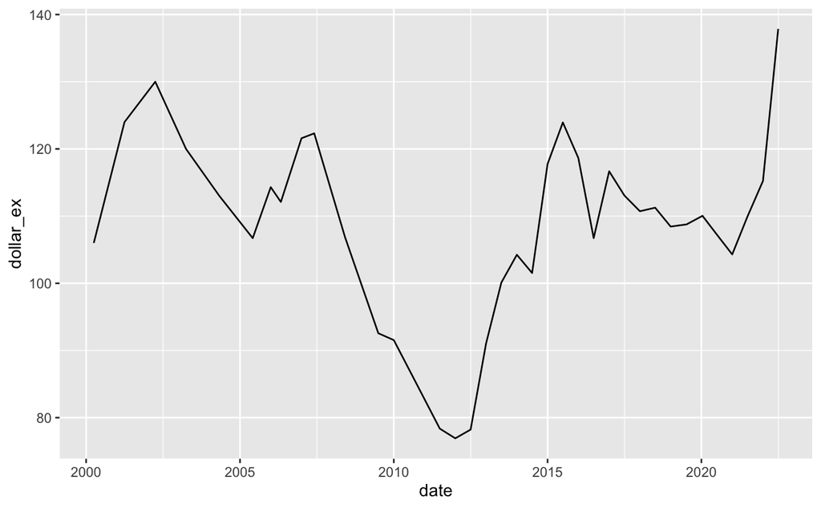

```r
bigmac %>% filter(name == "Japan") %>%
  ggplot(aes(date, dollar_ex)) + geom_line()
```

- **local_price**: Price of a Big Mac in the local currency
- **dollar_price**: Price of a Big Mac in dollars
- **dollar_ex**: Local currency units per dollar
- **USD_raw**: Raw index, relative to the US dollar
- **adj_price**: GDP-adjusted price of a Big Mac, in dollars
- **JPY_raw**: Raw index, relative to the Japanese yen
- **GDP_bigmac**:
- **GDP_dollar**: GDP per person, in dollars - in source
- **JPY_adjusted**: Adjusted index, relative to the Japanese yen

#### Mankiw’s Table, 2008 version

```r
bigmac_long %>% filter(date == '2008-06-01', name=='United States')
```

| date | iso_a3 | currency_code | name | local_price | dollar_ex | dollar_price | USD_raw | EUR_raw | GBP_raw | JPY_raw | CNY_raw | GDP_bigmac | adj_price | USD_adjusted | EUR_adjusted | GBP_adjusted | JPY_adjusted | CNY_adjusted | GDP_dollar | GDP_local |
| --- | --- | --- | --- | --- | --- | --- | --- | --- | --- | --- | --- | --- | --- | --- | --- | --- | --- | --- | --- | --- |
| 2008-06-01 | USA | USD | United States | 3.21 | 1 | 3.21 | 0 | -0.39918 | -0.29767 | 0.22502 | 0.75497 | 47943.35 | 4.26654 | 0 | -0.47661 | -0.35413 | 0.22857 | 0.27139 | 47943.35 | 47943.35 |

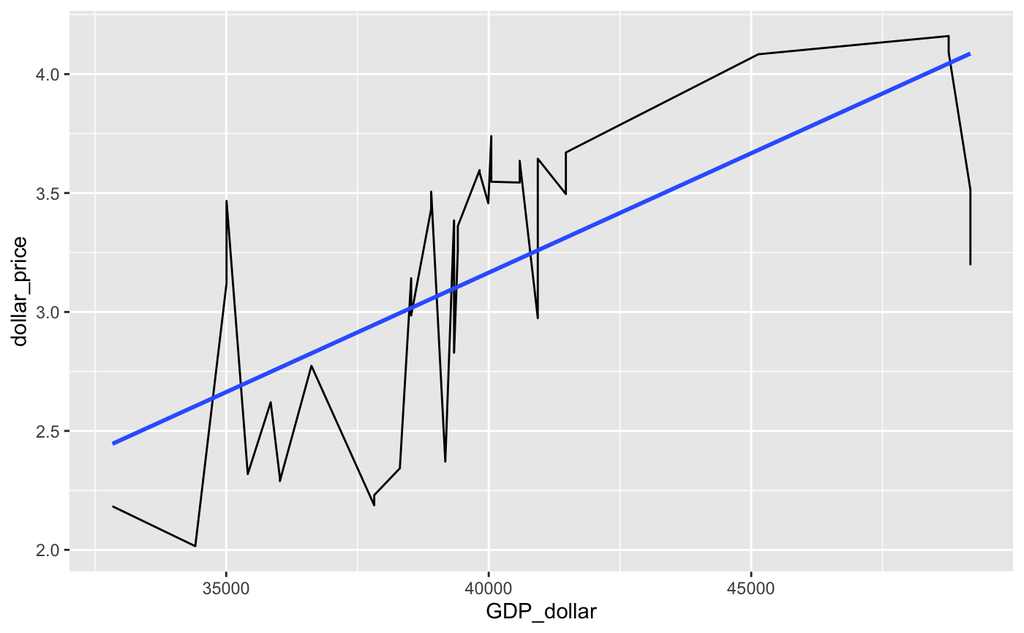

```r
bigmac_long %>% drop_na(dollar_price, GDP_dollar) %>%
  filter(name == "Japan") %>%
  ggplot(aes(GDP_dollar, dollar_price)) + geom_line() +
  geom_smooth(method = "lm", formula = y~x, se = FALSE)
```

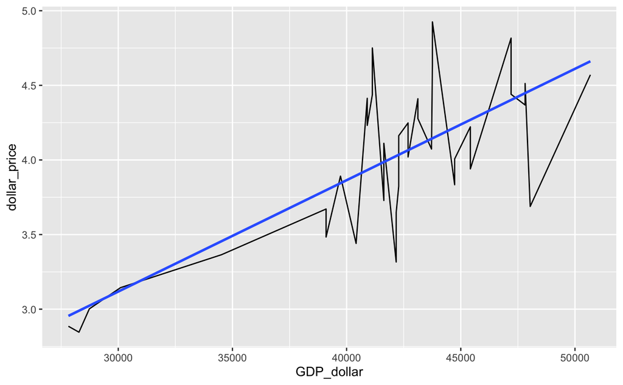

```r
bigmac_long %>% drop_na(dollar_price, GDP_dollar) %>%
  filter(name == "Britain") %>%
  ggplot(aes(GDP_dollar, dollar_price)) + geom_line() +
  geom_smooth(method = "lm", formula = y~x, se = FALSE)
```

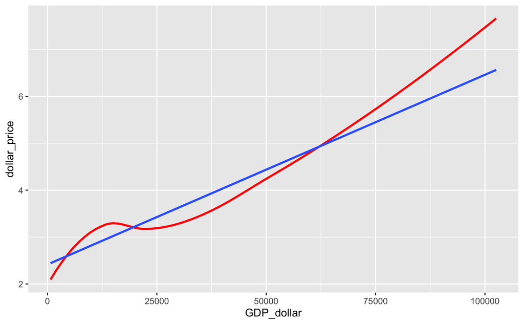

```r
bigmac_long %>% drop_na(dollar_price, GDP_dollar) %>%
  ggplot(aes(GDP_dollar, dollar_price)) +
  geom_smooth(method = "loess", formula = y~x, se = FALSE, col = "red") +
  geom_smooth(method = "lm", formula = y~x, se = FALSE)
```

```r
model <- bigmac_long %>% lm(dollar_price ~ GDP_dollar, .)
model2008 <- bigmac_long %>% filter(date == '2008-06-01') %>% lm(dollar_price ~ GDP_dollar, .)
```

```r
regression_countries = c('ARG', 'AUS', 'BRA', 'GBR', 'CAN', 'CHL', 'CHN', 'CZE', 'DNK',
                         'EGY', 'EUZ', 'HKG', 'HUN', 'IDN', 'ISR', 'JPN', 'MYS', 'MEX',
                         'NZL', 'NOR', 'PER', 'PHL', 'POL', 'RUS', 'SAU', 'SGP', 'ZAF',
                         'KOR', 'SWE', 'CHE', 'TWN', 'THA', 'TUR', 'USA', 'COL', 'PAK',
                         'IND', 'AUT', 'BEL', 'NLD', 'FIN', 'FRA', 'DEU', 'IRL', 'ITA',
                         'PRT', 'ESP', 'GRC', 'EST')
# in 2021, we added a number of additional countries to the adjusted index
regression_addons_2021 = c('ARE', 'CRI', 'LKA', 'UKR', 'URY', 'VNM', 'GTM', 'HND', 'NIC',
                           'AZE', 'BHR', 'HRV', 'JOR', 'KWT', 'MDA', 'OMN', 'QAT', 'ROU',
                           'SVK', 'SVN', 'LVA', 'LTU')
model <- bigmac_long %>% lm(dollar_price ~ GDP_dollar, .)
model2008 <- bigmac_long %>% filter(date == '2008-06-01') %>% lm(dollar_price ~ GDP_dollar, .)
model_new <- bigmac_long %>%
  filter(iso_a3 %in% regression_countries | iso_a3 %in% regression_addons_2021 & date >= as.Date('2021-01-01')) %>%
  lm(dollar_price ~ GDP_dollar, .)
```

```r
library(modelr)
bigmac_long %>% add_predictions(model, var = "pred") %>%
  add_predictions(model2008, var = "pred2008") %>%
  add_predictions(model_new, var = "pred_new") %>%
  filter(date == '2008-06-01') %>%
  select(name, adj_price, pred, pred2008, pred_new)
```

| name | adj_price | pred | pred2008 | pred_new |
| --- | --- | --- | --- | --- |
| UAE | NA | 4.093275 | 4.359215 | 4.092086 |
| Argentina | 3.129288 | 2.711380 | 2.730482 | 2.627393 |
| Australia | 4.326040 | 4.242324 | 4.534888 | 4.250066 |
| Brazil | 3.115738 | 2.714411 | 2.734054 | 2.630606 |
| Canada | 3.984270 | 4.224549 | 4.513939 | 4.231226 |
| Switzerland | 4.019917 | 5.076342 | 5.517881 | 5.134055 |
| Chile | 3.264281 | 2.847358 | 2.890749 | 2.771518 |
| China | 3.090906 | 2.524276 | 2.509957 | 2.429078 |
| Colombia | 3.072978 | 2.610992 | 2.612162 | 2.520990 |
| Costa Rica | NA | 2.665999 | 2.676995 | 2.579293 |

[output cut: 30 more lines]

```r
bigmac_us <- bigmac_long %>% filter(date == '2008-06-01', name=='United States') %>% pull(local_price)
bigmac_us
```

```
[1] 3.21
```

```r
gdppercap_us <- bigmac_long %>% filter(date == '2008-06-01', name=='United States') %>% pull(GDP_dollar)
gdppercap_us
```

```
[1] 47943.35
```

```r
library(modelr)
bigmac_long %>% filter(date == '2008-06-01') %>%
  drop_na(dollar_ex) %>% drop_na(GDP_dollar) %>%
  mutate(raw_in_dollar = local_price/dollar_ex) %>%
  mutate(ajusted_in_dollar = bigmac_us * GDP_dollar/gdppercap_us) %>%
  select(name, dollar_price, raw_in_dollar, adj_price, ajusted_in_dollar)
```

```r
bigmac_long %>% filter(date == '2008-06-01') %>%
  drop_na(dollar_ex) %>% drop_na(GDP_dollar) %>%
  mutate(raw_in_dollar = local_price/dollar_ex) %>%
  mutate(ajusted_in_dollar = bigmac_us * GDP_dollar/gdppercap_us) %>%
  select(name, dollar_price, raw_in_dollar, adj_price, ajusted_in_dollar)
```

| name | dollar_price | raw_in_dollar | adj_price | ajusted_in_dollar |
| --- | --- | --- | --- | --- |
| UAE | 2.722681 | 2.722681 | NA | 2.77673340 |
| Argentina | 3.642987 | 3.642987 | 3.129288 | 0.48981723 |
| Australia | 3.362573 | 3.362573 | 4.326040 | 3.02339722 |
| Brazil | 4.733056 | 4.733056 | 3.115738 | 0.49483390 |
| Canada | 4.075532 | 4.075532 | 3.984270 | 2.99398171 |
| Switzerland | 6.359145 | 6.359145 | 4.019917 | 4.40362439 |
| Chile | 3.133529 | 3.133529 | 3.264281 | 0.71484968 |
| China | 1.829090 | 1.829090 | 3.090906 | 0.18017647 |
| Colombia | 3.891808 | 3.891808 | 3.072978 | 0.32368430 |
| Costa Rica | 3.266669 | 3.266669 | NA | 0.41471618 |

[output cut: 30 more lines]

```r
bigmac %>% filter(date == '2008-06-01') %>% drop_na(dollar_ex) %>%
  mutate(raw_in_dollar = local_price/dollar_ex) %>%
  mutate(ajusted_in_dollar = bigmac_us * gdppercap_us /GDP_bigmac) %>%
  select(name, dollar_price, raw_in_dollar, adj_price, ajusted_in_dollar)
```

| name | dollar_price | raw_in_dollar | adj_price | ajusted_in_dollar |
| --- | --- | --- | --- | --- |
| UAE | 2.722681 | 2.722681 | NA | NA |
| Argentina | 3.642987 | 3.642987 | 3.129288 | 23.139470 |
| Australia | 3.362573 | 3.362573 | 4.326040 | 3.071591 |
| Brazil | 4.733056 | 4.733056 | 3.115738 | 24.987792 |
| Canada | 4.075532 | 4.075532 | 3.984270 | 4.082785 |
| Switzerland | 6.359145 | 6.359145 | 4.019917 | 3.947249 |
| Chile | 3.133529 | 3.133529 | 3.264281 | 13.321795 |
| China | 1.829090 | 1.829090 | 3.090906 | 29.273204 |
| Colombia | 3.891808 | 3.891808 | 3.072978 | 33.409919 |
| Costa Rica | 3.266669 | 3.266669 | NA | NA |

[output cut: 30 more lines]

```r
bigmac %>% filter(date == '2008-06-01') %>% mutate(raw_in_dollor = 3.21 * dollar_ex) %>%
  select(name, currency_code, local_price, dollar_price, predict)
```

```r
bigmac %>% filter(date == '2008-06-01') %>% mutate(predict = 3.21 * dollar_ex) %>%
  select(name, currency_code, local_price, dollar_price, predict)
```

| name | currency_code | local_price | dollar_price | predict |
| --- | --- | --- | --- | --- |
| UAE | AED | 10.00000 | 2.722681 | 11.789848 |
| Argentina | ARS | 11.00000 | 3.642987 | 9.692595 |
| Australia | AUD | 3.45000 | 3.362573 | 3.293460 |
| Brazil | BRL | 7.50000 | 4.733056 | 5.086566 |
| Canada | CAD | 4.09000 | 4.075532 | 3.221395 |
| Switzerland | CHF | 6.50000 | 6.359145 | 3.281101 |
| Chile | CLP | 1550.00000 | 3.133529 | 1587.826500 |
| China | CNY | 12.50000 | 1.829090 | 21.937140 |
| Colombia | COP | 7000.00000 | 3.891808 | 5773.666500 |
| Costa Rica | CRC | 1800.00000 | 3.266669 | 1768.774200 |

[output cut: 30 more lines]